# 객관식 문제

## 다음 중 명시적 데이터가 아닌 것을 모두 고르시오

1. 평점
2. 영상 시청 시간
3. 투표 수
4. 스케일 점수
5. 구매 기록

answer: 영상 시청 시간, 구매 기록

## 다음 중 오프라인 평가에 속하지 않는 것을 고르시오.

1. RMSE
2. F1-score
3. MAP
4. A/B Test
5. nDCG

answer: A/B test - 온라인

## 다음중 내용 기반 필터링 (Content-Based Filtering)의 장단점으로 옳지 않은 것을 모두 고르시오.

1. 한 유저의 정보만으로 추천시스템을 만들 수 있다.
2. 유저에 대한 콜드 스타트 문제를 해결할 수 있다.
3. Serendipity(흥미로움)을 확보할 수 있다.
4. 추천이 된 이유를 설명하기 용이하다.
5. 사용자가 평점을 매기지 않은 새로운 item이 들어올 경우에도 추천이 가능하다.

answer: 3? 5 사실 3은 헷갈립니다..

# 주관식 문제

## 명시적 데이터와 암묵적 데이터의 장단점을 2개씩 쓰시오. (장점 2개, 단점 2개)

answer  
명시적 장점: 당시의 사용자의 취향이 정확하게 반영됨  
명시적 단점: 사람의 취향은 변하기 마련임. 지금은 바뀌었을 수 있다.  
암묵적 장점: 데이터를 얻기 쉬움  
암묵적 단점: 사람의 취향을 직접적으로 알 수 없다.

## 협업 필터링에 속하는 필터링 2가지를 쓰시오. (큰 분류 2가지)

answer: 사용자 기반 / 아이템 기반

## 아래 user의 relevance가 사진과 같을 때, DCG @ 5을 계산하시오.

단, 수식을 작성해도 된다. log의 밑은 실제로 2이지만 생략해도 된다.

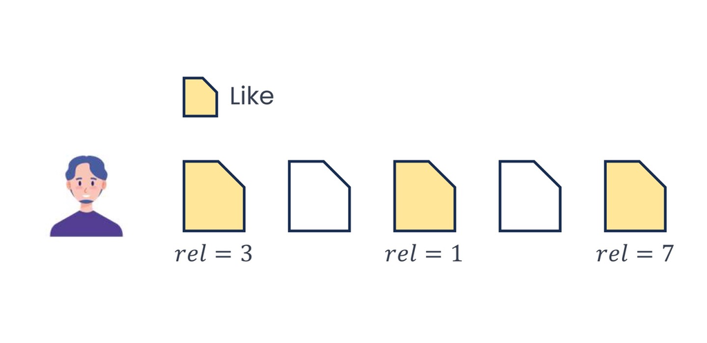

answer: 3 + 0/log_2(2) + 1/log_2(3) + 0/log_2(4) + 7/log_2(5)

## 아래 두 유사도의 설명 중, 빈칸에 들어갈 말을 쓰시오. (***)

코사인 유사도: 아이템 사이의 * **를 이용하여 유사도를 측정

answer: 벡터 사이의 각도

피어슨 유사도: 아이템의 * 를 이용하여 측정

answer: 벡터간 선형 상관 관계

## TF(d, t)와 DF(t)의 차이점에 대해 설명하시오.

answer:  
TF: 문서 d에 등장한 단어 t의 등장 횟수  
DF: 단어 t가 등장한 문서 수

수고하셨습니다!